# 02. 벡터의 확장 개념

```python
import numpy as np
import matplotlib.pyplot as plt

import matplotlib_inline.backend_inline
plt.rcParams.update({'font.size':14})
```

## 02.01. 벡터 집합

- 집합 : 벡터들의 모음

$$S=\{v_1, \dots, v_n \}$$

## 02.02. 선형 가중 결합 (Linear Weighted Combination)

- 여러 변수마다 가중치를 다르게 주어 정보를 혼합하는 방법
- 벡터 집합에서 각 벡터에 스칼라를 곱한 다음 이들을 더하여 하나의 벡터를 만듬

$$W = \lambda_1 v_1 + \lambda_2 v_2 + \dots \lambda_n v_n$$

- 모든 벡터 $v_i$의 차원은 같다고 가정
- $\lambda$는 0을 포함한 임의의 실수

$$\lambda_1=1, \lambda_2 = 2, \lambda_3 = -3, v_1=\begin{bmatrix} 4\\5\\1\end{bmatrix}, v_2=\begin{bmatrix} -4\\0\\-4\end{bmatrix}, v_3=\begin{bmatrix} 1\\3\\2\end{bmatrix}$$

$$W=\lambda_1 v_1 + \lambda_2 v_2 + \lambda_3 v_3=\begin{bmatrix} -7\\-4\\-13\end{bmatrix}$$

```python
l1 = 1
l2 = 2
l3 = -3

v1 = np.array([4,5,1])
v2 = np.array([-4,0,-4])
v3 = np.array([1,3,2])

l1*v1 + l2*v2 + l3*v3
```

```
array([ -7,  -4, -13])
```

- 선형 가중 결합
  - 통계모형의 최소제곱 알고리즘
  - 주성분 분석과 같은 차원 축소 과정에서 각 성분의 분산을 최대화 하는 가중치와 데이터 채널의 선형 가중 결합
  - 인공 신경망의 선형 가중 결합 등에서 활용

## 02.03. 선형 독립성

- **선형 종속성 (Linear dependent) : 벡터 집합에서 적어도 하나의 벡터를 집합의 다른 벡터들의 선형 가중 결합으로 나타낼 수 있을 때의 벡터 집합**
- **선형 독립적 (Linear independent) : 집합에 있는 벡터들의 선형 가중 결합으로 집합의 아무런 벡터도 나타낼 수 없을 때의 벡터 집합**
- 아래의 벡터 집합 $V$는 선형 독립적, $S$는 선형 종속성을 만족

$$V = \begin{Bmatrix} {\begin{bmatrix} 1\\3\end{bmatrix}}, {\begin{bmatrix} 2\\7\end{bmatrix}} \end{Bmatrix}\;\;\;S = \begin{Bmatrix} {\begin{bmatrix} 1\\3\end{bmatrix}}, {\begin{bmatrix} 2\\6\end{bmatrix}} \end{Bmatrix}$$

- 아래의 벡터 집합 $T$는 선형 종속성을 만족 : 처음 세 벡터의 합은 네 번째 벡터의 두 배와 같음

$$T = \begin{Bmatrix} {\begin{bmatrix} 8\\-4\\14\\6 \end{bmatrix}}, {\begin{bmatrix} 4\\6\\0\\3\end{bmatrix}}, {\begin{bmatrix} 14\\2\\4\\7\end{bmatrix}}, {\begin{bmatrix} 13\\2\\9\\8\end{bmatrix}} \end{Bmatrix}$$

- 모든 벡터 집합은 선형 독립적이거나 선형 종속적일 수 있으며, 집합 내의 개별 벡터의 속성이 아님

### 수학에서의 선형 독립성

- 선형 종속적이라면, 집합의 벡터들의 선형 가중 결합으로 영벡터를 만들 수 있음

$$0 = \lambda_1 v_1 + \lambda_2 v_2 + \dots + \lambda_n v_n,\;\;\;\lambda \in \mathbb{R}$$

- 위 식을 참으로 만드는 $\lambda$를 찾을 수 있다면, 벡터 집합은 선형 종속적이며

  이 식을 참으로 만드는 $\lambda$를 찾을 수 없다면, 벡터 집합은 선형 독립적

### 독립성과 영벡터

- 영벡터가 포함된 모든 벡터 집합은 당연히 선형 종속적인 집합

$$\lambda_00 = 0v_1 + 0 v_2 + 0 v_n$$

- 따라서, $\lambda_1 \neq0 $이며, 자명하지 않은 해 (nontrivial solution)이 존재한다면, 그 집합은 선형 종속성 정의에 부합

## 02.04. 부분공간과 생성

- **유한한 벡터 집합의 동일한 벡터를 사용하지만, 다른 가중치 숫자를 사용해서 무한히 선형 결합하는 방식으로 벡터 부분공간 (Sub space)을 생성**
- **가능한 모든 선형 가중 결합을 구성 : 벡터 집합의 생성 (span)**

#### 즉, 생성 (span)을 통하여 벡터 부분공간을 (sub space)를 만듬

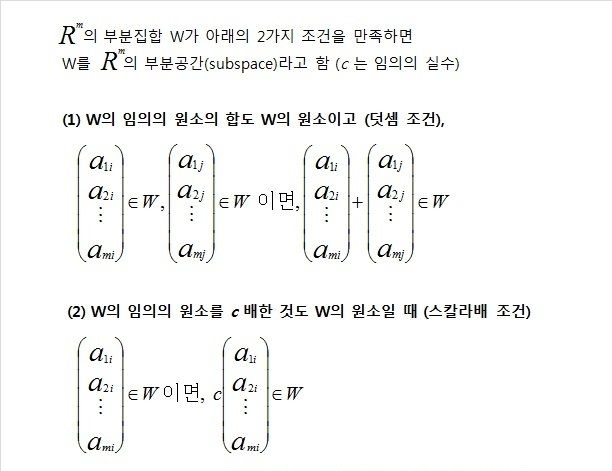

#### 벡터 집합에서 생성되는 부분공간의 차원은 선형 독립 집합을 형성하는 데 필요한 최소한의 벡터수

- **벡터 집합이 선형 독립적이면, 해당 집합의 벡터들로 생성된 부분공간의 차원은 집합의 벡터 수와 동일**
- **벡터 집합이 선형 종속적이면, 해당 집합의 벡터들로 생성된 부분공간의 차원은 반드시 해당 집합의 벡터 수보다 작음**

#### 벡터 부분공간의 공식적인 정의

- 덧셈과 스칼라 곱셈으로 닫혀 있는 부분집합으로 공간의 원점을 포함

  즉, 부분공간에 존재하는 벡터들의 선형 가중 결합 또한 동일한 부분공간에 반드시 존재하며

  모든 가중치를 0으로 설정해서 만들어진 공간의 원점인 영벡터도 마찬가지

#### 하나의 벡터를 가진 벡터 집합

$$V = \begin{Bmatrix} {\begin{bmatrix} 1\\3\end{bmatrix}} \end{Bmatrix}$$

- 벡터 집합의 생성은 집합의 벡터들의 선형 결합으로 만들 수 있는 무한한 벡터

  하지만, 하나의 벡터만 있는 집합이라면, 단순히 그 벡터의 가능한 모든 크기의 벡터가 됨

#### 두 벡터를 가진 벡터 집합

- 벡터는 $\mathbb{R}^3$에 존재

$$V = \begin{Bmatrix} {v_1}, {v_2} \end{Bmatrix}$$

- 2차원 부분공간이 생성

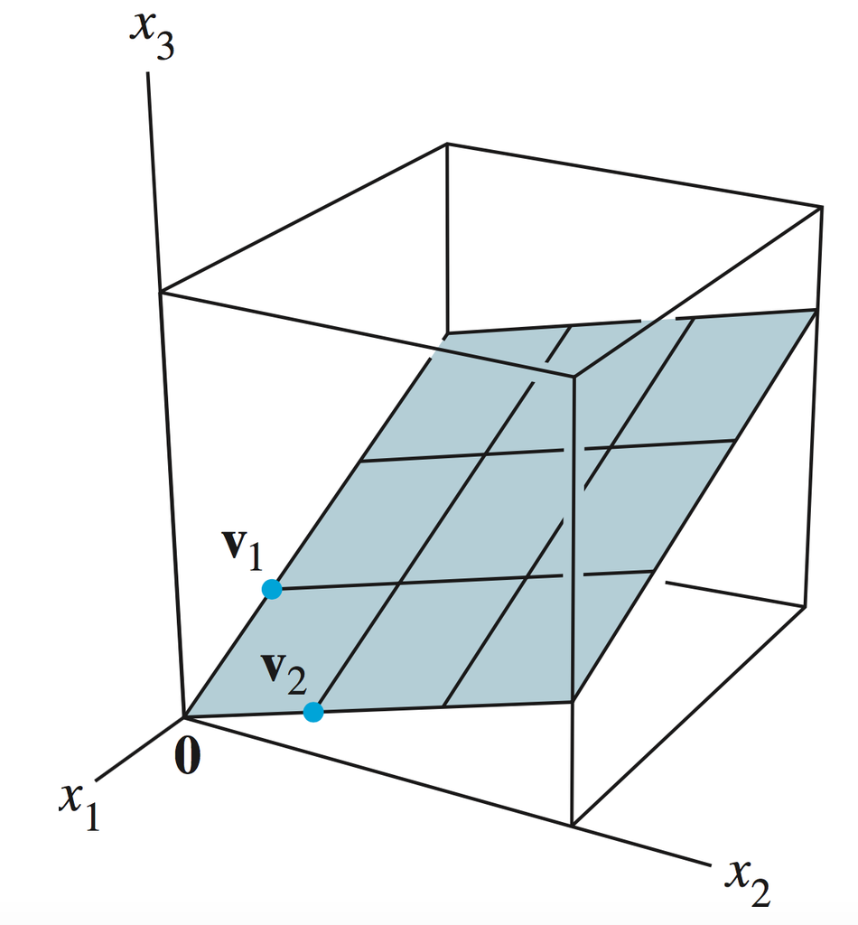

#### 만약, 두개의 벡터가 아래와 같이 선형관계라면

- **집합의 한 벡터가 이미 다른 벡터의 생성 안에 존재하기에, 생성 측면에서 두 벡터 중 하나는 중복**

  **$\rightarrow$ 부분공간은 1차원**

$$V = \begin{Bmatrix} {\begin{bmatrix} 1\\1\\1\end{bmatrix}}, {\begin{bmatrix} 2\\2\\2\end{bmatrix}} \end{Bmatrix}$$

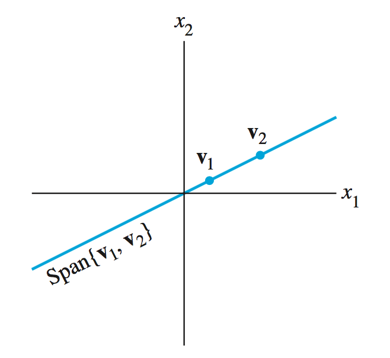

## 02.05. 기저

- **기저 (basis) : 행렬의 정보를 설명하는 데 사용하는 자 (ruler)의 집합**

  동일한 데이터를 다양한 자로 설명할 수 있음

#### 데카르트 좌표계 (Cartesian Coordinate System)

- 데카르트 기저 집합은 서로 직교하며 단위 길이인 벡터로 이루어져 있음 (표준 기저 집합, Standard Basis Set)
- 2차원과 3차원 데카르트 그래프 기저 집합

$$S_2 = \begin{Bmatrix} {\begin{bmatrix} 1\\0\end{bmatrix}}, {\begin{bmatrix} 0\\1\end{bmatrix}} \end{Bmatrix}\;\;S_3 = \begin{Bmatrix} {\begin{bmatrix} 1\\0\\0\end{bmatrix}}, {\begin{bmatrix} 0\\1\\0\end{bmatrix}}, {\begin{bmatrix} 0\\0\\1\end{bmatrix}} \end{Bmatrix}$$

- $\mathbb{R}^2$의 또 다른 기저집합

$$T = \begin{Bmatrix} {\begin{bmatrix} 3\\1\end{bmatrix}}, {\begin{bmatrix} -3\\1\end{bmatrix}} \end{Bmatrix}$$

#### 선형대수학에서 점은 기저벡터의 선형 결합으로 표현

#### 점 $p=(3, 1)$, $q=(-6, 2)$에 대하여

- **기저벡터 $S_2$의 벡터로 표현 : $p=3s_1 + s_2\;\;\;q=-6s_1+2s_2$**
- **기저벡터 $T$의 벡터로 표현 : $p=1t_1 + 0t_2\;\;\;q= 0t_1+2t_2$ $\;\;\;\rightarrow\;\;\;$ $p=t_1,\;\;\;q=2t_2$로 간결하게 표현**

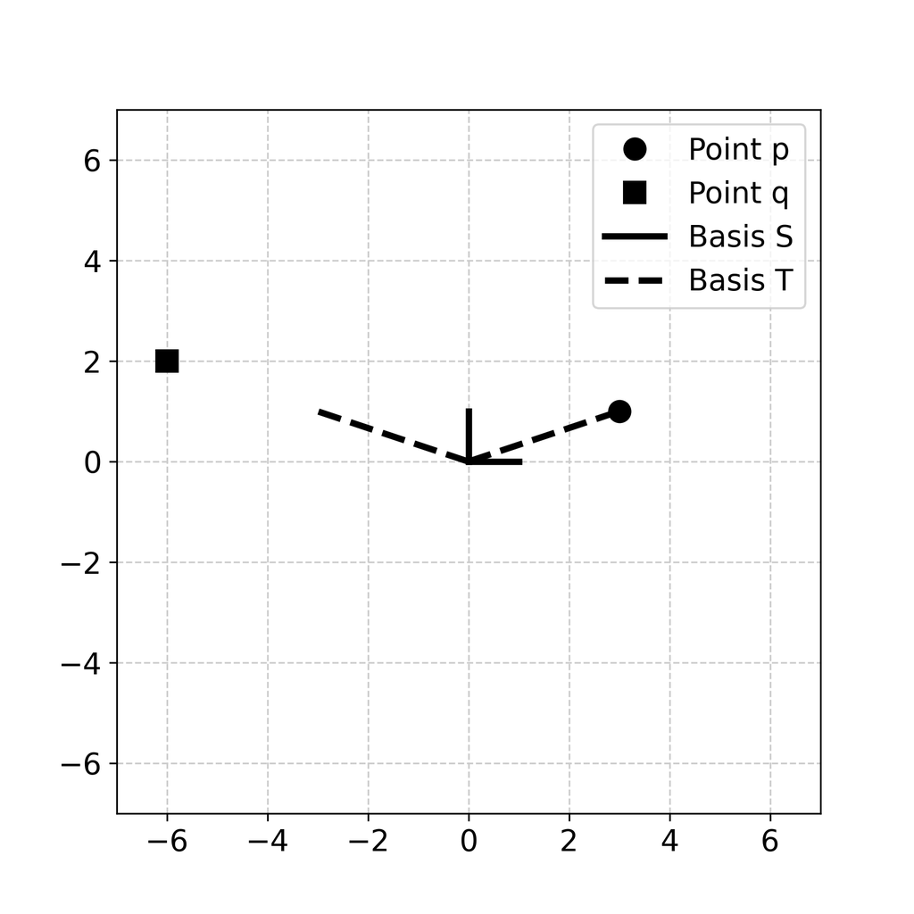

#### 선형대수학의 많은 문제는 어떤 부분공간에 대한 최적의 기저벡터 집합을 찾는 것으로 개념화

- 차원 축소, 특징 추출, 주성분 분석, 독립성분 분석, 요인 분석, 특잇값 분해, 선형판별분석, 이미지 근사, 데이터 압축 등
- 어떤 기저 집합도 본질적으로 더 낫거나 나쁘다고 할 수 없으며, 분석의 목표와 데이터의 특성, 분석의 제약 조건에 따라 달라짐

### 기저의 정의

- **벡터 집합이 특정 부분공간을 생성하고, 독립적인 벡터 집합이라면 해당 부분공간의 기저**
- **기저가 어떤 부분공간의 기저가 되려면, 해당 부분공간을 생성할 수 있어야 함**

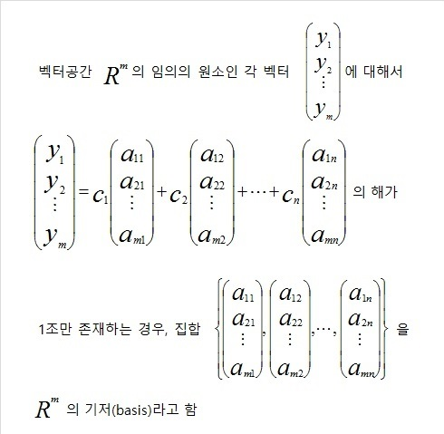

- **아래의 벡터 집합 $U$를 통하여 $p$를 설명할 수 있는 선형 가중 결합 계수는 $(3, 0, 1),\;(0, 1.5, 1)$등 수많은 개수가 존재**

  **$\rightarrow$ 따라서 $U$는 $p$의 기저 집합이 아님**

$$U = \begin{Bmatrix} {\begin{bmatrix} 1\\0\end{bmatrix}}, {\begin{bmatrix} 2\\0\end{bmatrix}}, {\begin{bmatrix} 0\\1\end{bmatrix}} \end{Bmatrix}$$

#### 모든 벡터가 기저 집합 내에서 하나의 점은 정확히 하나의 선형 가중 결합으로 정의됨